# Predicting Weeks on Billboard for Rolling Stone’s Top 500 Album

Author

Roy Chen, Ritisha Jhamb, and Aarav Mahajan

# Summary

Here, we attempt to build a regression model using the k-nearest neighbors (kNN) algorithm to predict the number of weeks an album spends on the Billboard chart `weeks_on_billboard` based on characteristics such as `release_year`, `peak_billboard_position`, and `spotify_popularity`. This model could help music industry analysts, artists, and record labels understand the factors that contribute to an album’s longevity on the chart and make informed decisions about marketing and production strategies.

Our current model has a prediction error, as measured by the Root Mean Squared Error (RMSE), of approximately 74.71 weeks. This model has room for improvement, given that the weeks_on_billboard values has an Interquartile range of about 50 weeks.

# Introduction

| Variable | Class | Description |
| --- | --- | --- |
| sort_name | character | Name used for sorting |
| clean_name | character | Clean name |
| album | character | Album name |
| rank_2003 | double | Rank in 2003. NA if album not released yet or not in top 500 |
| rank_2012 | double | Rank in 2012. NA if album not released yet or not in top 500 |
| rank_2020 | double | Rank in 2020. NA if not in top 500 |
| differential | double | 2020-2003 Differential. Negative value if it went down in the chart. Positive value if it went up. |
| release_year | double | Release Year |
| genre | character | Album Genre |
| type | character | Album Type |
| weeks_on_billboard | double | Weeks on Billboard |
| peak_billboard_position | double | Peak Billboard Position |
| spotify_popularity | double | Spotify Popularity. NA if not on Spotify |
| spotify_url | character | Spotify URL. NA if not on Spotify |
| artist_member_count | double | Number of artists in the group |
| artist_gender | character | Gender of the artist(s). Male/Female if it’s a mixed-gender group |
| artist_birth_year_sum | double | Sum of the artists’ birth years |
| debut_album_release_year | double | Debut Album Release Year |
| ave_age_at_top_500 | double | Average age at top 500 Album |
| years_between | double | Years Between Debut and Top 500 Album |
| album_id | character | Album ID. NOS at the beginning of the ID if not on Spotify |

Part of the dataset shows the album rankings on the Billboard 200 Chart. The latter is a widely recognized measure of an album’s commercial success. Understanding the factors that contribute to an album’s longevity on the chart can provide valuable insights for artists, record labels, and music industry analysts. For example:

Artists: Can use this information to plan album releases and marketing strategies.

Record Labels: Can identify trends and allocate resources effectively.

Analysts: Can predict the potential success of new albums based on historical data.

In this project, we aim to answer the following question: Can we use characteristics of an album (e.g., release year, peak chart position, Spotify popularity) to predict how long it will stay on the Billboard chart?

To answer this question, we used a k-nearest neighbors (kNN) regression model and data from Rolling Stone’s rankings. We found that our model has a prediction error of approximately 74.71 weeks, which is reasonable given the variability in the data. However, there is room for improvement, as the model explains 13.95% of the variability in weeks_on_billboard.

# Methodolgy

## Importing the data

We imported the data set from TidyTuesday’s Github into the data directory. Using domain expertise and exploartory analysis, we chose to focus on the following predictor variables:

Table 1. Predictor variables used for analysis, chosen for their utility by domain expertise.

[output not shown]

## Preliminary Analysis

### Loading The Necessary Libraries

The necessary packages and libraries from the R programming language used in this analysis include `tidyr`, `dplyr`, `readr`, `ggplot2`, `ggpubr` and `caret`.

### Wrangling

The data set used in this project was cleaned and prepared for analysis through several steps. First, numerical columns which had a large number of missing values(25% of total) and were poorly correlated as found in the EDA later were removed. Categorical variables like sort_name, clean_name, album(name), spotify_url, etc. were removed, as they were not relevant to the analysis, and it would be difficult to use these variables as they are close to unique identifiers. Next, missing values were handled: the genre and type columns were imputed using the most frequent strategy, and the weeks_on_billboard column was imputed using the mean strategy, as removing these would have significantly skewed the analysis. Rows with missing values in other columns were dropped to ensure a complete dataset. Finally, all numeric predictors were scaled to ensure equal weighting in the kNN algorithm. These steps resulted in a clean, analysis-ready dataset.

### Data Splitting

The data was partitioned into training (80%) and testing (20%) sets. The relationship between weeks_on_billboard and the predictor variables was visualized using scatter plots and boxplots to assess their utility for predictive modeling. Correlation was also used to assess the relationship betweent the response and the predictors.

## Exploratory Analysis

In the exploratory data analysis (EDA), we first examined relationships between numeric variables and weeks_on_billboard using scatter plots with linear trendlines. This helped us visualize potential linear associations and identify predictors that might be strongly related to the target variable. Correlation values were also computed to quantify the strength of these relationships, highlighting which variables have positive or negative impacts on Billboard longevity.

Furthermore, we explored categorical variables — genre, artist_gender, and type — through boxplots to assess how weeks_on_billboard varies across different categories. These visualizations provided insights into how factors like album type and artist gender may influence chart success, and revealed potential group-level differences that could be important for modeling. Overall, the EDA gave a clearer picture of key patterns and relationships in the data.

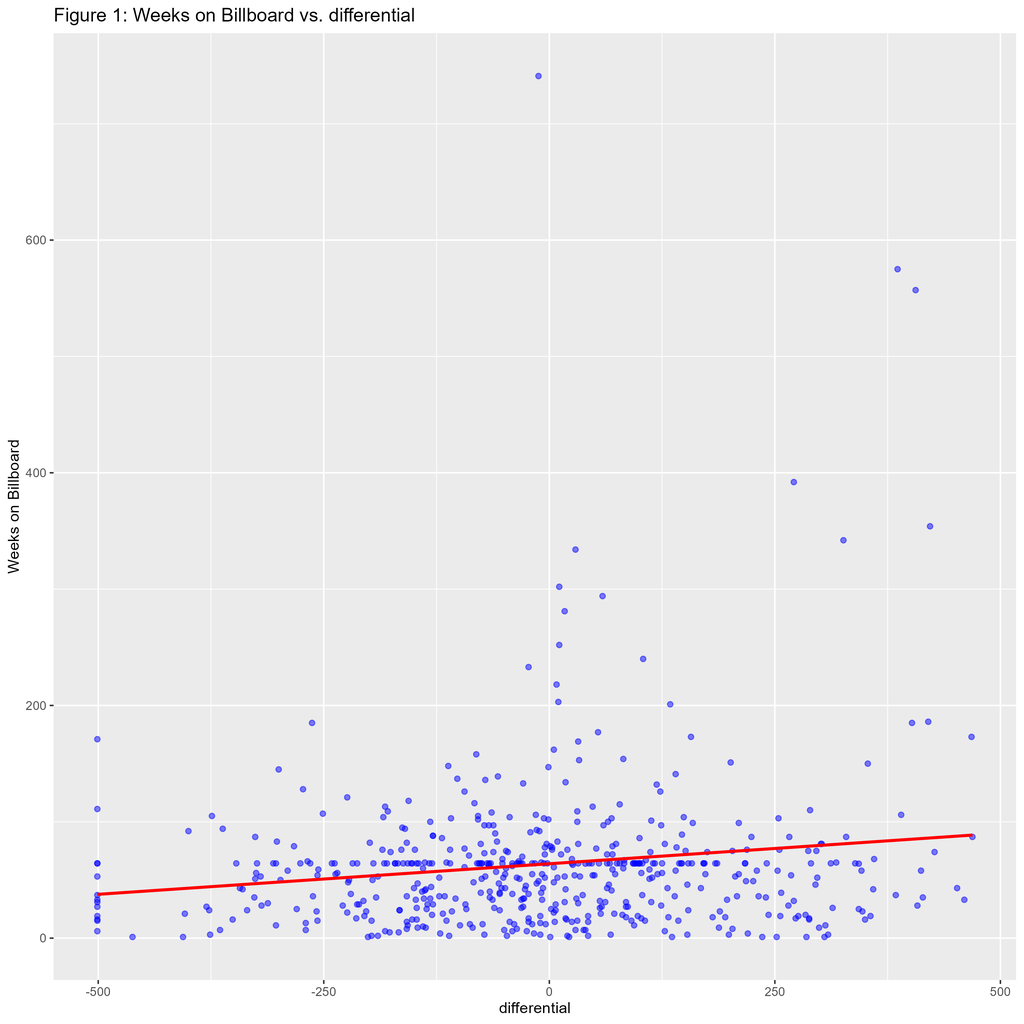

Figure 1: Weeks on Billboard Vs Change in Album’s Ranking from 2003 to 2020

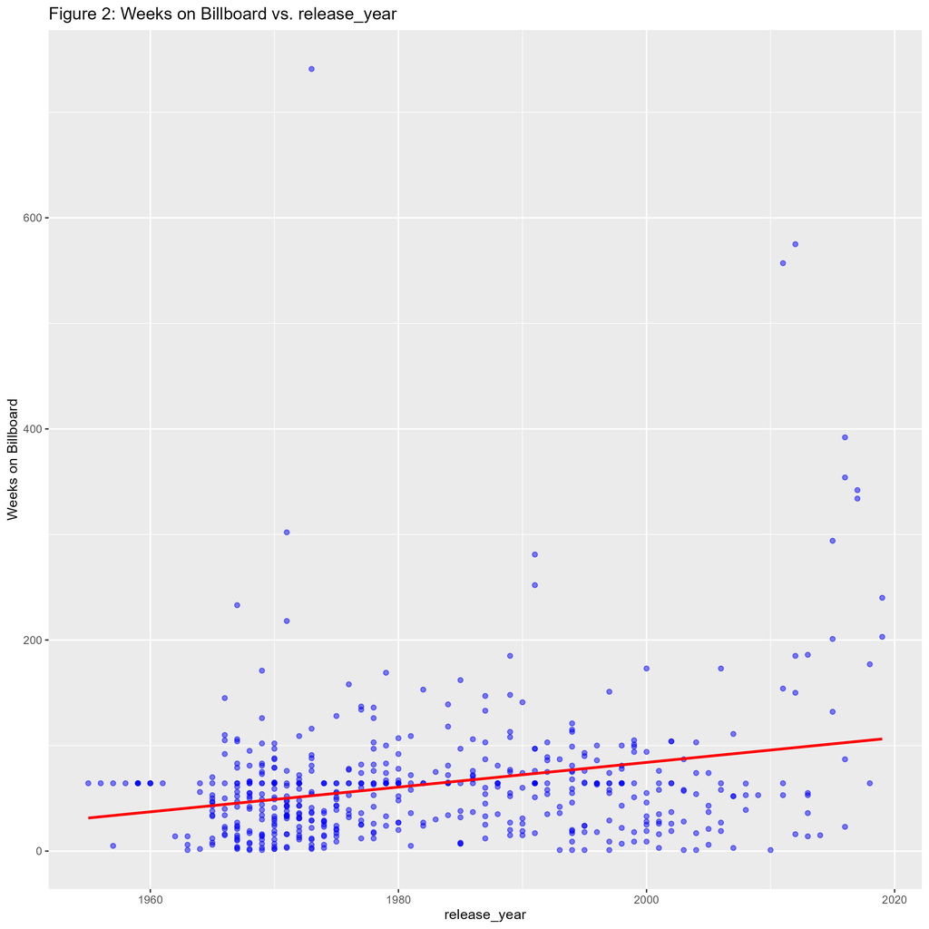

Figure 2: Weeks on Billboard Vs Release Year

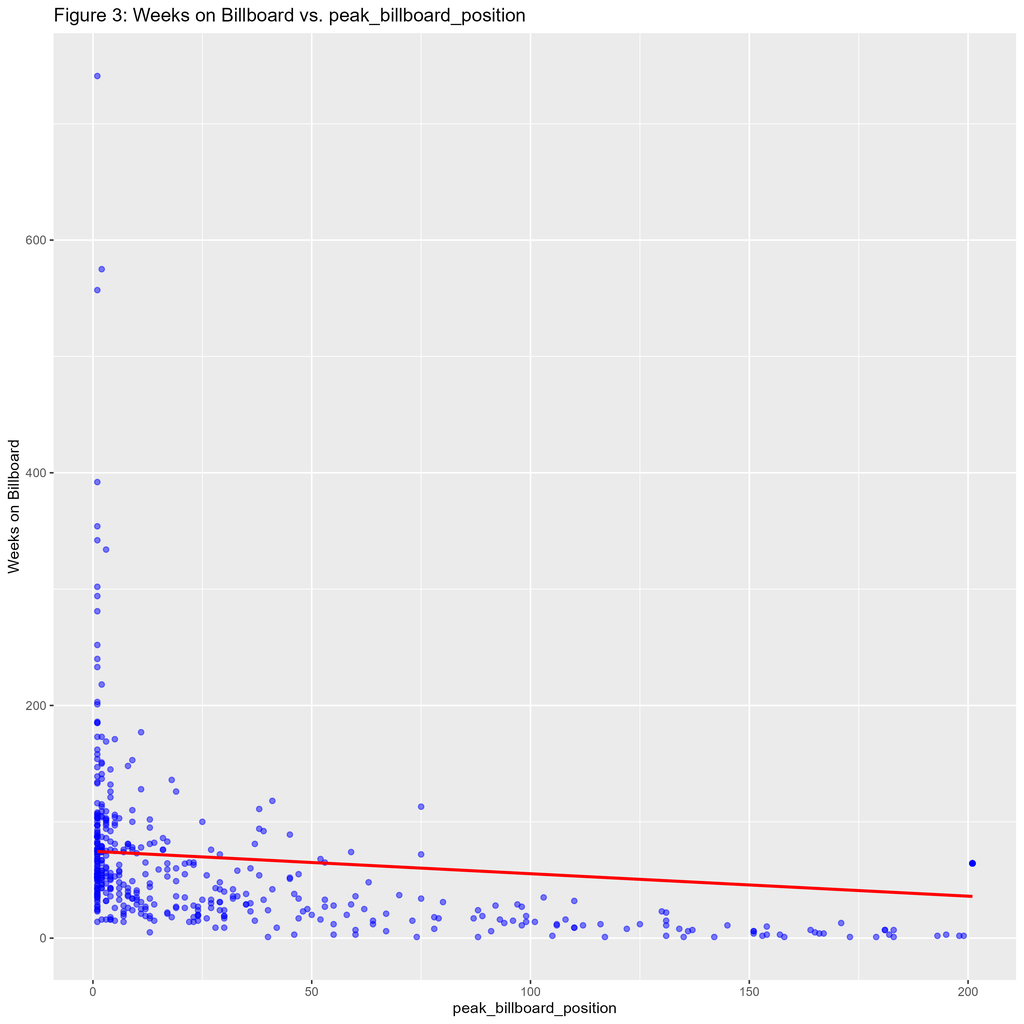

Figure 3: Weeks on Billboard Vs Peak Billboard Position

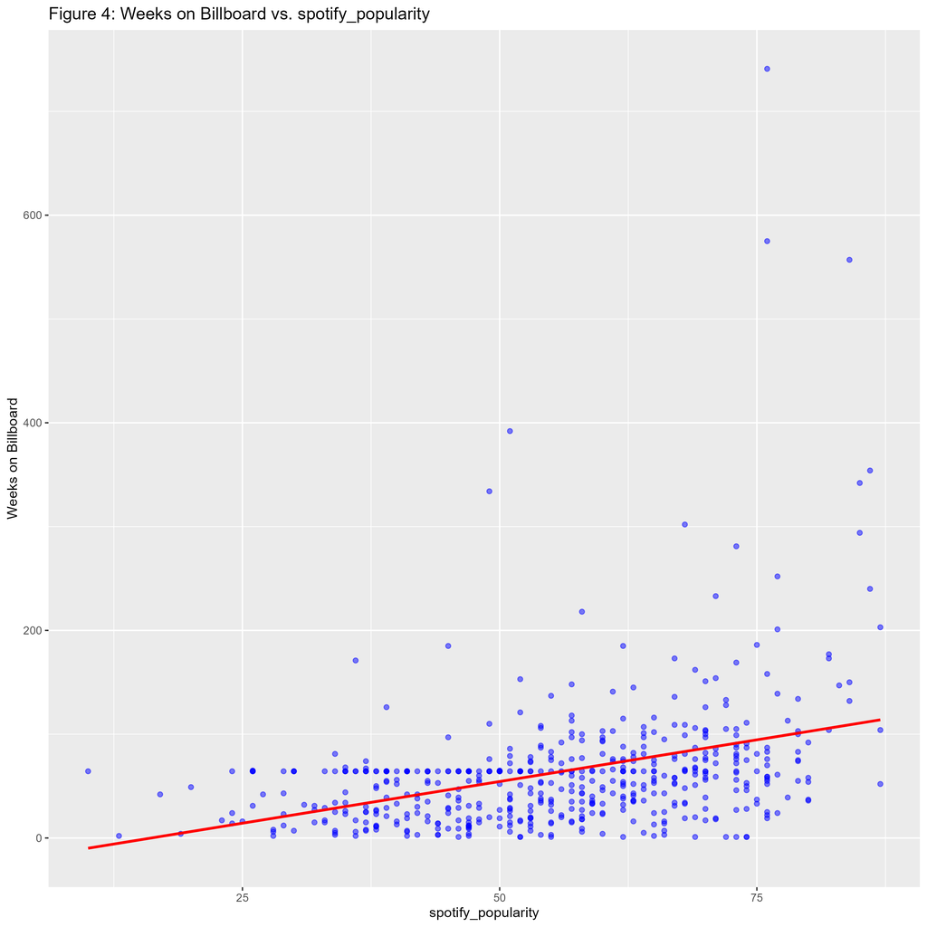

Figure 4: Weeks on Billboard Vs Spotify Popularity

[figure not shown]

Figure 5: Weeks on Billboard Vs Artist Member Count

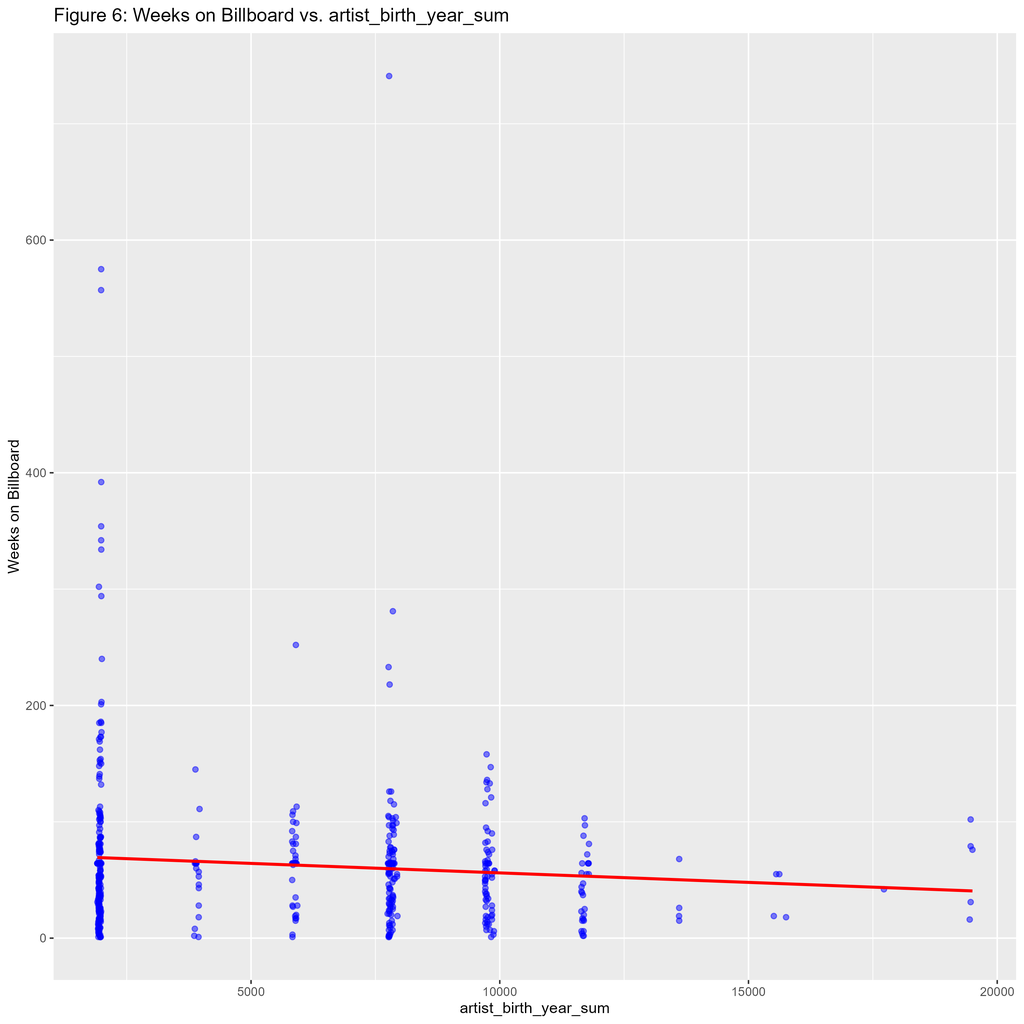

Figure 6: Weeks on Billboard Vs Artist Birth Year Total

[figure not shown]

Figure 7: Weeks on Billboard Vs Debut Album Release Year

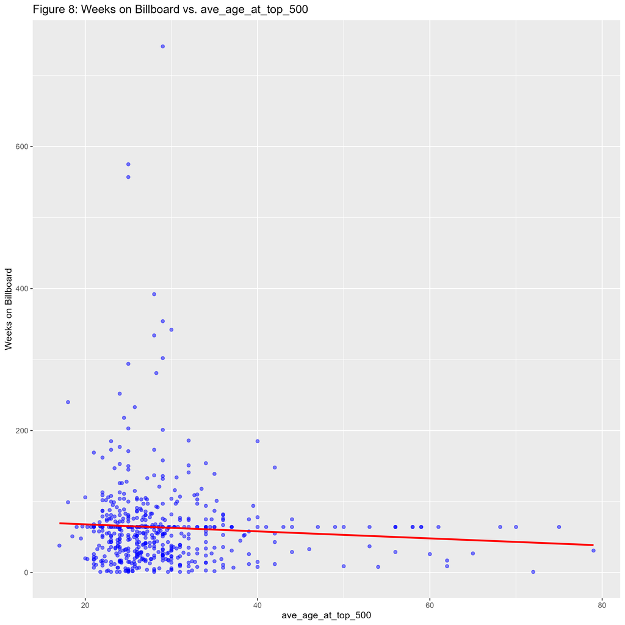

Figure 8: Weeks on Billboard Vs Average Age

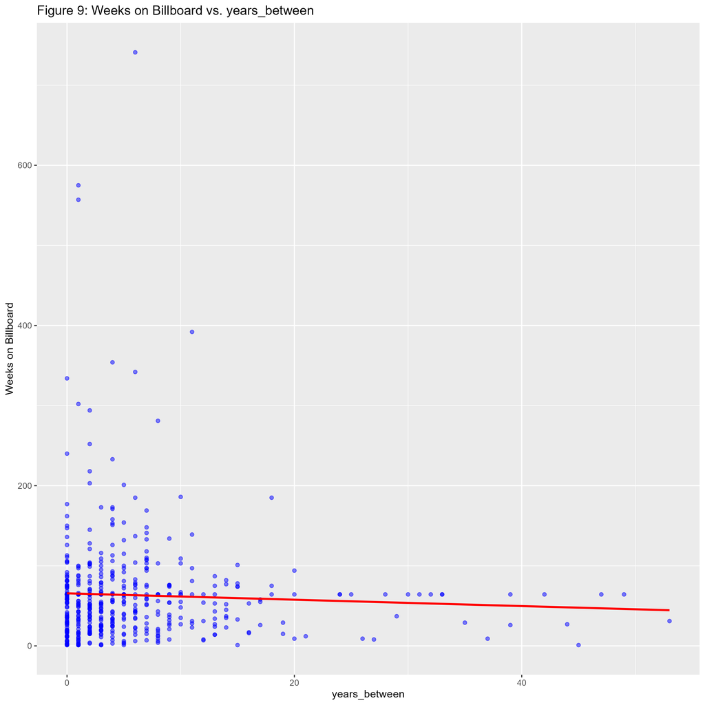

Figure 9: Weeks on Billboard Vs Age of the Album Relative to the Debut Album

Predictor Analysis

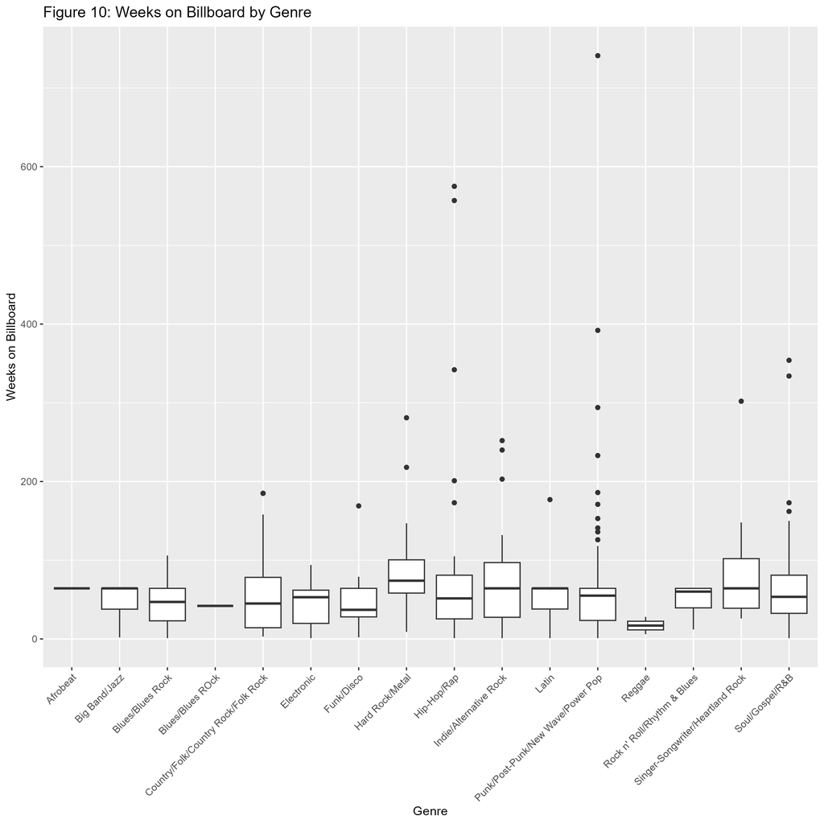

Figure 10: Weeks on Billboard By Music Genre of Album

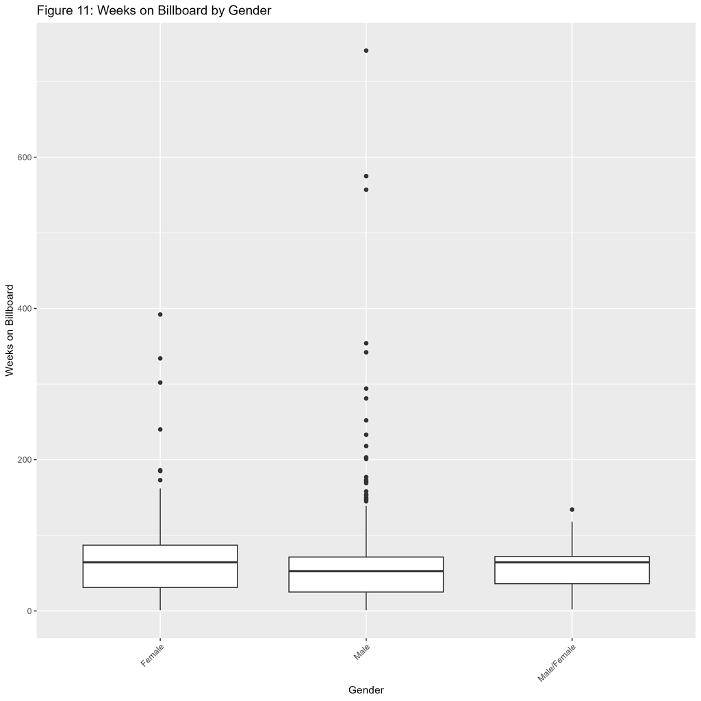

Figure 11: Weeks on Billboard By Gender

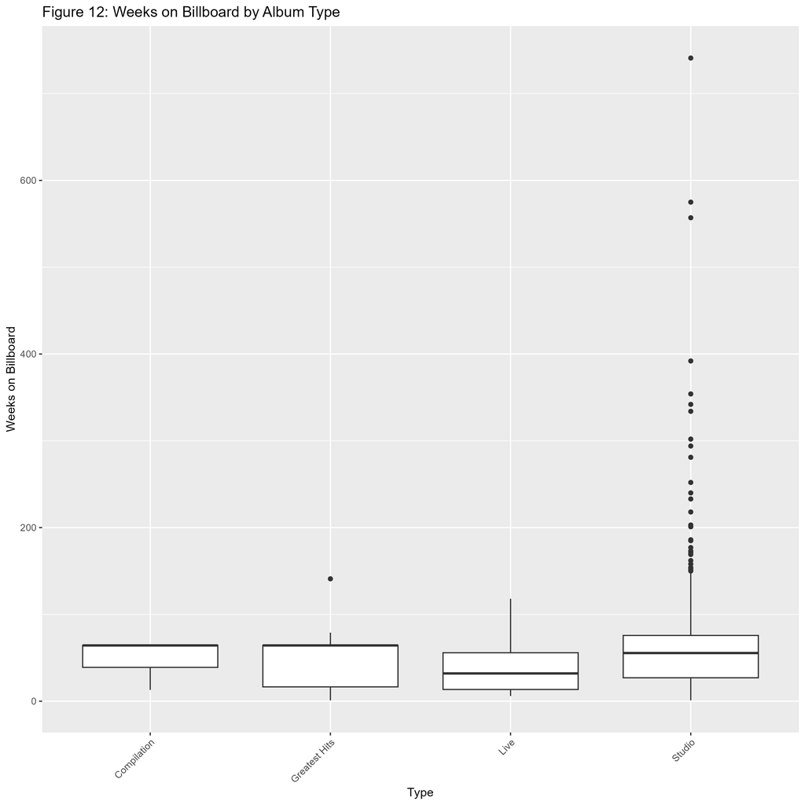

Figure 12: Weeks on Billboard By Music Presentation

Album Type Analysis

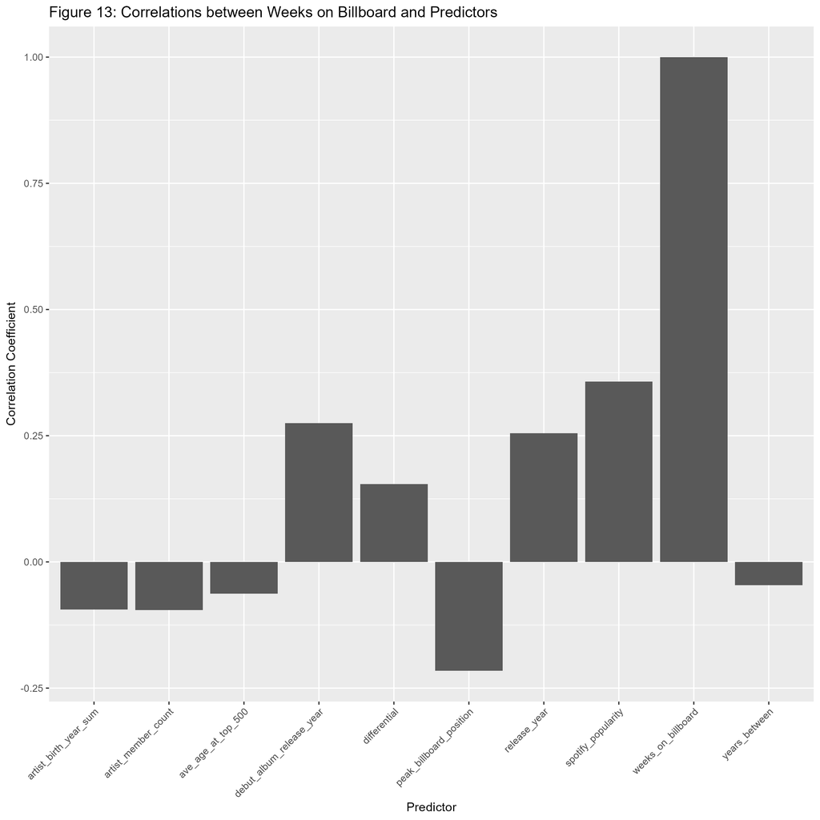

Figure 13: Predictor Barplot

## Predictor Selection and Model Execution

For predictor selection, we focused on identifying variables that had meaningful relationships with weeks_on_billboard and were relevant to understanding album success. Variables with an absolute correlation greater than 0.2 were prioritized, as these are more likely to contribute valuable information to the model. Based on this criterion, we selected release_year, peak_billboard_position, spotify_popularity, and debut_album_release_year as predictors. Variables with weak correlations, such as differential, artist_member_count, and artist_birth_year_sum, were excluded to prevent unnecessary complexity and reduce the risk of overfitting.

After selecting predictors, we cleaned and scaled the datasets using min-max normalization to ensure all numeric variables were on a comparable scale. We also handled mismatches in categorical levels between training and testing datasets by filtering out unseen categories from the test set. A k-Nearest Neighbors (kNN) model was then trained using 5-fold cross-validation to tune the optimal value of k, evaluating performance with RMSE. The final model was assessed on the test set, where both RMSE and R-squared were calculated to measure prediction accuracy and explained variance. This process ensured a robust approach to selecting meaningful predictors and building a well-tuned predictive model.

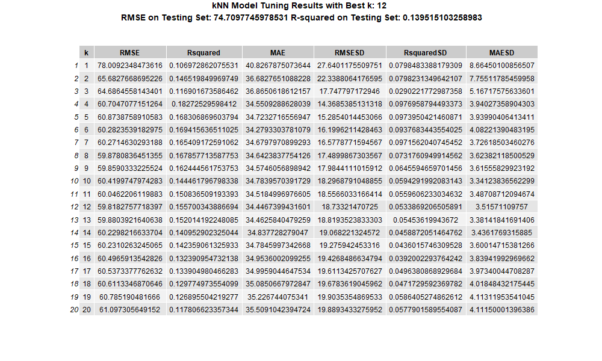

Figure 14: knn-tuning results

# Discussion

Our interpretation of the data: The correlations between the predictors and the weeks on the billboard were generally weak. The variable that correlated with the weeks on the billboard most was the spotify popularity, which is expected since both are direct measurements of the popularity of the album. The correlation was 0.36. The variable that correlated with the weeks on the billboard the least was the years between the release date of the album and the first album the artist released. This was a bit surprising since people might expect more experienced artists to make more popular works. The correlaton was -0.05.

# References

News (2022) Morris (2022) Bove (n.d.) Richter (2018)

## References

Bove, K. n.d. “What Is Popular Music?” n.d. https://kaitlinbove.com/what-is-popular-music.

Morris, E. 2022. “Why Do Artists Peak Early?” *The Boar*. https://theboar.org/2022/01/why-do-artistspeak-early/.

News, Global. 2022. “Old Music Now More Popular Than New Songs: Report.” https://globalnews.ca/news/8540223/old-music-more-popular-than-new-songs/.

Richter, Felix. 2018. “The Most Popular Music Genres Worldwide.” https://www.statista.com/chart/15763/most-popular-music-genres-worldwide/.